# Maryland Violent Crime Statewide Totals by Type

### *Different type of major crimes over the year*

```python
import plotly.graph_objects as go
import numpy as np

# create figure with year list as x and larceny_theft list as y
fig2 = go.Figure(data=go.Scattergl(
    x = year,
    y = larceny_theft,
    mode='lines',
    name='Larceny crime',
    marker=dict(
        color='blue',
        colorscale='Viridis',
        line_width=1
    )
))
# Adding different lines representing different crimes into the figure using add_trace.
fig2.add_trace(go.Scatter(x=year, y=b_e,
                    mode='lines',
                    name='Breaking and Entering'))
fig2.add_trace(go.Scatter(x=year, y=assault,
                    mode='lines',
                    name='Assault crime'))
fig2.add_trace(go.Scatter(x=year, y=violent_tol,
                    mode='lines',
                    name='Violent crime'))
fig2.add_trace(go.Scatter(x=year, y=roberry,
                    mode='lines',
                    name='Roberry crime'))
# Update layout
fig2.update_layout(
    title="Different type of major crime over the year",
    xaxis_title="Year",
    yaxis_title="Crimes cases",
    font=dict(
        family="Courier New, monospace",
        size=12,
        color="black"
    )
)

fig2.show()
```

[interactive chart not shown]

In according to this, it is significant to see that assault and roberry crime witness the stable throughout the year and seem to be good under control with relatively high by the end of the most current year report. Meanwhile, violent crime and breaking and entering seem to be fluctuate over the years with more ups and down and the line representing violent crime seemts to has a curve by the end after slope. This indicating the risk of violent crime that need to be pay attention on since it is on the rise. Meanwhile, breaking and entering crime is on the down flow and relatively low in 2017.

*Note:* For the purpose of the research, I would like to take one external reference to gather the list of population and unemployment rate of Maryland through our targeted years in order to compare/test with the variables of our source to learn deeper insight our findings toward the main data. Though the main finding throughout this report is still based upon our based data wrangled from json.

```python
# Gather population in Maryland from 1975 to 2017
# source indicated in reference part.
population = [6025000,6003323,5985562,5957283,5923188,5886992,5839419,5788645,5730388,5684965,5653408,5627367,5592379,5546935,
5496269,5440389,5374691,5311034,5171634,5130072,5092914,5057142,5023650,4985411,4942504,4902545,4856176,4797431,
4727301,4657904,4565557,4486957,4413071,4365243,4313327,4282923,4261905,4227643,4191160,4183603,4169595,4150539,4139096]
```

```python
list.reverse(population)
```

```python
# Update in our dictionary as reference field
for i in range(len(population)):
    crime_list[i]['Population'] = population[i]
```

```python
# Gather unemployment rate in Maryland from 1975 to 2017
# source indicated in reference part.
unemploy_rate = [5.3, 6.6, 6.3, 5.5, 5.8, 6.6, 7.3, 8.3, 7, 5.4, 4.6, 4.6, 4.4, 4.3, 3.8, 4.5, 6.1, 6.8, 6.2, 5.3, 5,5.1,5,4.4,3.6,3.6,4,4.4,4.4,4.3,4.1,3.9,3.4,4.2,7,7.6,7.3,7,6.6,5.8,5.1,4.5,4.3]
```

```python
for i in range(len(unemploy_rate)):
    crime_list[i]['Unemployment rate'] = unemploy_rate[i]
```

```python
# Let's take a glance of what we have
crime_list[5]
```

```
{'year': 1980,
 'homicide': 399.0,
 'rape': 1681.0,
 'roberry': 16462.0,
 'assault': 17182.0,
 'b_e': 71130.0,
 'larceny_theft': 152089.0,
 'mv_theft': 18885.0,
 'grandtotal': 277828.0,
 'percent_change': 6.3,
 'violent_tol': 35724.0,
 'vio_perc': 12.9,
 'vio_change': 7.9,
 'prop_crime': 242104.0,
 'prop_per': 87.1,
 'prop_change': 6.1,
 'Population': 4227643,
 'Unemployment rate': 6.6}
```

```python
# Let's see what the record looks like when population reach the peak.
seq2 = [x['Population'] for x in crime_list]
max(seq2)
next(item for item in crime_list if item["Population"] == max(seq2))
```

```
{'year': 2017,
 'homicide': 569.0,
 'rape': 1773.0,
 'roberry': 11295.0,
 'assault': 17049.0,
 'b_e': 23735.0,
 'larceny_theft': 99119.0,
 'mv_theft': 13553.0,
 'grandtotal': 167093.0,
 'percent_change': -0.9,
 'violent_tol': 30686.0,
 'vio_perc': 18.4,
 'vio_change': 5.8,
 'prop_crime': 136407.0,
 'prop_per': 81.6,
 'prop_change': -2.2,
 'Population': 6025000,
 'Unemployment rate': 4.3}
```

```python
# Let's see what the record looks like when population reach the peak.
seq2 = [x['Unemployment rate'] for x in crime_list]
max(seq2)
next(item for item in crime_list if item["Unemployment rate"] == max(seq2))
```

```
{'year': 1982,
 'homicide': 431.0,
 'rape': 1596.0,
 'roberry': 15377.0,
 'assault': 18845.0,
 'b_e': 60547.0,
 'larceny_theft': 142903.0,
 'mv_theft': 16719.0,
 'grandtotal': 256418.0,
 'percent_change': -8.3,
 'violent_tol': 36249.0,
 'vio_perc': 14.1,
 'vio_change': -4.3,
 'prop_crime': 220169.0,
 'prop_per': 85.9,
 'prop_change': -8.9,
 'Population': 4282923,
 'Unemployment rate': 8.3}
```

## 4. Findings part 3: Explore Correlations

```python
from sklearn import preprocessing
import numpy as numpy
population_norm = preprocessing.scale(population)
vio_change_norm = preprocessing.scale(vio_change)
prop_change_norm = preprocessing.scale(prop_change)
lar_norm = preprocessing.scale(larceny_theft)
```

```python
# violent change versus larceny theft
print(numpy.corrcoef(vio_change,larceny_theft))
```

```
[[1.         0.07549322]
 [0.07549322 1.        ]]
```

```python
# violent change versus property change
print(numpy.corrcoef(vio_change,prop_change))
```

```
[[1.         0.57342169]
 [0.57342169 1.        ]]
```

```python
# violent change versus roberry
print(numpy.corrcoef(vio_change,roberry))
```

```
[[1.         0.19057628]
 [0.19057628 1.        ]]
```

```python
# violent change versus assault
print(numpy.corrcoef(vio_change,assault))
```

```
[[1.         0.01319414]
 [0.01319414 1.        ]]
```

```python
# violent change versus total property crime
print(numpy.corrcoef(vio_change,prop_crime))
```

```
[[1.        0.1562577]
 [0.1562577 1.       ]]
```

```python
# violent change versus rape crime
print(numpy.corrcoef(vio_change,rape))
```

```
[[1.        0.4392408]
 [0.4392408 1.       ]]
```

```python
# violent change versus population
print(numpy.corrcoef(vio_change,population))
```

```
[[ 1.         -0.30496969]
 [-0.30496969  1.        ]]
```

```python
# violent change versus homicide
print(numpy.corrcoef(vio_change,homicide))
```

```
[[1.         0.07358646]
 [0.07358646 1.        ]]
```

Looking at these results above, it is significant to define that there are some realtionship between violent change to other factor like unemployment rate, population, property change, roberry, rape crime. These pairs indicatings both of the same direction and opposite direction of the violent change based on the sign of the coefficient results representing variances and provide comprehensie overview of which aspects we should dig deep in to discovery through simple linear regression and multiple linear regression.In the next section, we will dig deep into these direction to predict the potential direction of these relationships.

## 5. Findings part 4: Linear and Multiple Linear Regression

### Model 1

Let's explore the relationship between violent change rate and rape crimes.

```
R square of this model is 0.19293247732654242
```

```
(-10.665, 10.565)
```

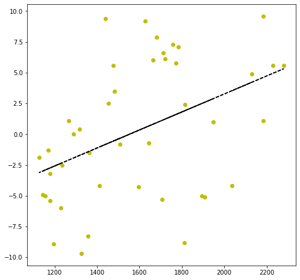

```python
import scipy
slope, intercept, r_value, p_value, std_err = scipy.stats.linregress(rape,vio_change)
print("R square of this model is" , r_value**2)
coef = np.polyfit(rape,vio_change,1)
poly1d_fn = np.poly1d(coef)
# poly1d_fn is now a function which takes in x and returns an estimate for y

plt.plot(rape,vio_change, 'yo', rape, poly1d_fn(rape), '--k')
plt.xlim()
plt.ylim()
```

```python
# violent change versus unemploy rate
import numpy
print(numpy.corrcoef(vio_change,unemploy_rate))
```

```
[[ 1.         -0.13948677]
 [-0.13948677  1.        ]]
```

```python
scipy.stats.linregress(rape, vio_change)
```

```
LinregressResult(slope=0.0073148277442991695, intercept=-11.361715223369208, rvalue=0.4392407965188826, pvalue=0.0032107457236467706, stderr=0.002336492763297842)
```

This model has square value being 19.29% while p value is 0.003.

The dots representing the variable distribute equally but are not really formed the line. The r square value of the model is not high and could explain 19.29% of the variable. P value is signficant, which also indicate the potential in the relationship between rape crime cases and violent crime rate change.

### Model 2

Let's explore the relationship between violent change rate and property crime.

```
R square of this model is 0.024416469187732073
```

```
(-10.665, 10.565)
```

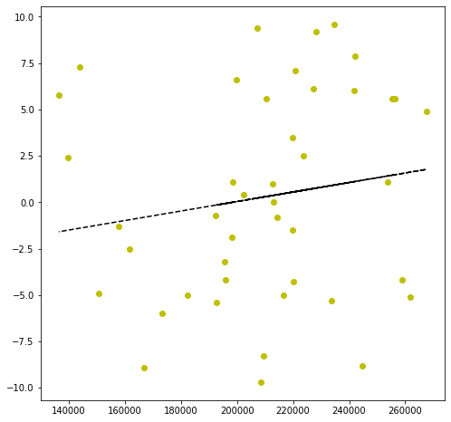

```python
import scipy
slope, intercept, r_value, p_value, std_err = scipy.stats.linregress(vio_change, prop_crime)
print("R square of this model is" , r_value**2)
coef = np.polyfit(prop_crime,vio_change,1)
poly1d_fn = np.poly1d(coef)
# poly1d_fn is now a function which takes in x and returns an estimate for y

plt.plot(prop_crime,vio_change, 'yo', prop_crime, poly1d_fn(prop_crime), '--k')
plt.xlim()
plt.ylim()
```

```python
scipy.stats.linregress(vio_change, prop_crime)
```

```
LinregressResult(slope=953.2476352247884, intercept=208806.74424809, rvalue=0.15625770121095495, pvalue=0.3170103545022892, stderr=941.0324668878269)
```

This model has square value being 2.44 % while p value is 0.317.

The dots representing the variable distribute equally but are not formed as a fitted line. The r square value of the model is low and could not explain well the variable. P value is not signficant, which also indicate the lack of element to prove the relationship between property crime and violent crime rate change.

### Model 3

Let's explore the relationship between violent change rate and property crimes change rate.

```
R square of this model is 0.32881243247012093
```

```
(-10.665, 10.565)
```

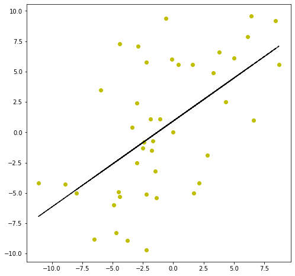

```python
import scipy
slope, intercept, r_value, p_value, std_err = scipy.stats.linregress(vio_change, prop_change)
print("R square of this model is" , r_value**2)
coef = np.polyfit(prop_change,vio_change,1)
poly1d_fn = np.poly1d(coef)
# poly1d_fn is now a function which takes in x and returns an estimate for y

plt.plot(prop_change,vio_change, 'yo', prop_change, poly1d_fn(prop_change), '--k')
plt.xlim()
plt.ylim()
```

```python
scipy.stats.linregress(vio_change, prop_change)
```

```
LinregressResult(slope=0.46399912649343317, intercept=-1.0541579018598413, rvalue=0.5734216881755703, pvalue=5.835016468283305e-05, stderr=0.10353163470962964)
```

This model has square value being 32.88 % while p value is 5.835e-05 indicates the strong relationship between change rate of violent crime and change rate of property crime. the model seems to fit the line, and it could explain 32.88% the variant of the data.

### Model 4

Let's explore the relationship between violent change rate and population. At first, let's normalize our data.

```python
norm_pop = []
for i in range(len(population)):
    norm_pop.append((population[i] - min(population))/(max(population) - min(population)))
```

```python
vio_norm = []
for i in range(len(vio_change)):
    vio_norm.append((vio_change[i] - min(vio_change))/(max(vio_change) - min(vio_change)))
```

```
R square of this model is 0.09300651111795676
```

```
(-0.05, 1.05)
```

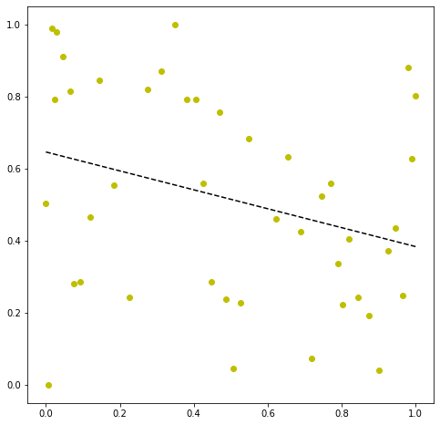

```python
slope, intercept, r_value, p_value, std_err = scipy.stats.linregress(norm_pop, vio_norm)
print("R square of this model is" , r_value**2)
coef = np.polyfit(norm_pop, vio_norm,1)
poly1d_fn = np.poly1d(coef)
# poly1d_fn is now a function which takes in x and returns an estimate for y

plt.plot(norm_pop, vio_norm, 'yo', norm_pop, poly1d_fn(norm_pop), '--k')
plt.xlim()
plt.ylim()
```

```python
scipy.stats.linregress(norm_pop, vio_norm)
```

```
LinregressResult(slope=-0.26236317017480815, intercept=0.6460407018135689, rvalue=-0.3049696888511328, pvalue=0.046751526157455446, stderr=0.1279547314235885)
```